# Problem Set 7 Notes

Stat 341 – Spring 2017

## R Markdown stuff

1. Please make reasonably sized plots.

   I suggest you use the template in the `rethinking` package as a starting point. You can always make an ocassional plot larger as needed.
2. Watch your code formatting

   In particular, avoid long lines that don’t fit on the page.
3. Use code comments correctly

   In-code comments are for comments on your code, not for a discussion of the results. Put discussion in text blocks, not code blocks.
4. Use the space bar

   Use a space after commas, mathematical operators (`+`, `*`, etc.), and comment symbols (`#`)

See also my comments from PS 6.

## Printer issues

Some of your printers don’t do well with shading. Here is a way to turn off shading and run on an outline if you use `gf_ribbon()`

```r
gf_ribbon(ymin + ymax ~ x, data = ..., color = "navy", fill = NA)
```

Choosing a gray background is also problematic if your printer doesn’t handle grays well. If you use the Rmd template in the `rethinking` package you will see that it includes the line

```r
theme_set(theme_minimal())
```

This sets up `ggplot2` and `ggformula` to use a white background (among other things) and will likely look better on a black and white printer.

Also, note that `ggplotly()` only works in HTML documents. You will want to leave that out of printed work since you can’t interact with printed plots.

## Bad variable name – my bad

`LDS.prop` in my code isn’t actually a proportion, it is a percent. I should have checked more carefully what I was getting from Wikipedia. A better name would be `LDS.perc`.

## Plotting counterfactual data

### Group sizes are integers

You know this, of course. But when you fix the value of group size to the mean group size, that might not be an integer. Probably best to choose an integer value.

### Multiple fits on one plot

Here is an example of how to plot multiple counterfactual plots on top of each other.

```r
fox.map <- map(
  alist(
    weight ~ dnorm(mu, sigma),
    mu <- a + bA * area + bG * groupsize,
    a ~ dnorm(10, 5),
    c(bA, bG) ~ dnorm(0, 5),
    sigma ~ dunif(0, 5)
  ),
  data = foxes,
)
fox.pred1 <-
  expand.grid(
    area = seq(1, 5, by = 0.2),
    groupsize = c(2, 4, 6)
  )
fox.link <- link(fox.map, data = fox.pred1)
```

```
## [ 100 / 1000 ]
[ 200 / 1000 ]
[ 300 / 1000 ]
[ 400 / 1000 ]
[ 500 / 1000 ]
[ 600 / 1000 ]
[ 700 / 1000 ]
[ 800 / 1000 ]
[ 900 / 1000 ]
[ 1000 / 1000 ]
```

```r
fox.pred1 <-
  fox.pred1 %>%
  mutate(
    weight.pred = apply(fox.link, 2, mean),
    weight.link.lo = apply(fox.link, 2, PI)[1,],
    weight.link.hi = apply(fox.link, 2, PI)[2,]
    )
```

Facets or colors (or both) can be used to show multiple predictions on one plot. The use of `factor()` forces things to be treated as categorical even though they are coded as numbers. This is required for the ribbons in the first plot.

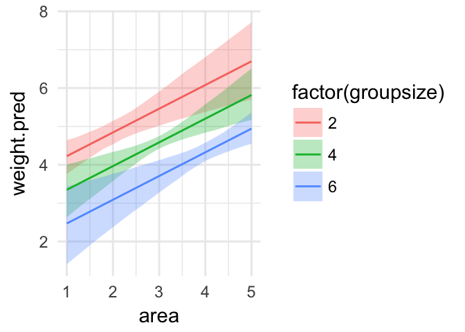

```r
gf_ribbon(weight.link.lo + weight.link.hi ~ area + fill::factor(groupsize),
          data = fox.pred1) %>%
  gf_line(weight.pred ~ area + color::factor(groupsize), data = fox.pred1)
```

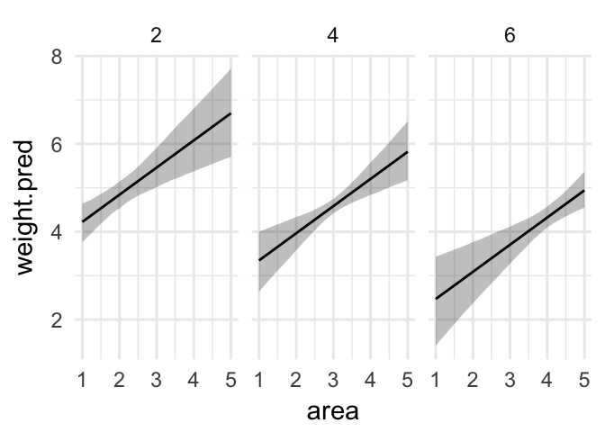

```r
gf_ribbon(weight.link.lo + weight.link.hi ~ area, data = fox.pred1) %>%
  gf_line(weight.pred ~ area, data = fox.pred1) %>%
  gf_facet_grid(~groupsize)
```

If you choose to overlay raw data, you want to make sure that you only use data from groups of the sizes your predictions correspond to.